# CREiGS 2023

Author: Chris Porras

## R crash course

Welcome to R! This will be a brief crash course of the basic computational techniques that we will be using in this week’s lab. Please work through this pre-lab assignment BEFORE starting the lab. Keep in mind that this pre-lab assignment will be 15 completion points.

Some quick vocabulary: * chunk: the darker grey space denoted by ``` is a convenient container for you to write your code inside of. Clicking on the green arrow on the top-right of the chunk runs just the segment of code that you write inside of it. You can also use ctrl + shift + enter to run the current chunk. Chunks display their output in a window below them.

- bug: any error that may occur when you run code. Bugs will often result in error messages displayed in the chunk which will need to be troubleshooted before the chunk will run.
- argument: a variable, vector, matrix, or parameter, that is fed into a function for a specified output.
- func(): the () denote functions. Functions can be fed inputs, or arguments, and will perform operations and provide an output when run.
- initialize or preallocate: in our case, this describes the process by which we create a blank vectors or matrices to contain our desired output after performing our desired operations. Preallocation sets aside a place in memory for our code to send its output. This is particularly important when we run loops.
- loop: a segment of code that iterates, or repeats, whatever code is contained within it based on predetermined rules.
- nested loop: a loop within a loop. The innermost loop runs first for however many times the outermost loop specifies. This is useful for iterating over multiple dimensions (like in a 2D matrix).
1. Variable assignments and arithmetic

Variables hold data in forms like integers, strings, decimals, etc. You can assign a value to variables with the “<-” assignment operator. Values assigned to variables are called ‘parameters’ or ‘constants’ and stored in memory to be ‘called’ by their names in other operations.

When performing assignemnts, the names don’t really matter as long as you are consistent with them. It is good coding practice to use descriptive but brief names.

You can do standard arithmetic with variables and the (+,-,*,/,^) operators. exp() is the exponential function. The variable provided in the exp() raises e^ to the value of the variable.

```r
##### Examples #####
a  <- 3
b  <- 2

a + b
```

```
## [1] 5
```

```r
a * b
```

```
## [1] 6
```

```r
a^b
```

```
## [1] 9
```

```r
exp(a)
```

```
## [1] 20.08554
```

Write code using variable assignments to show the results of the following:

5^27

e^(27)

5/27

```r
###### YOUR CODE HERE ######
```

Answers: [1] 7.450581e+18 [1] 532048240602 [1] 0.1851852

2. Creating vectors and vector arithmetic Vectors can be thought of as a 1-dimensional list of values. Vectors can be created using the c() to ‘combine’ values in a list. The colon : can also create a vector of values from start:stop counting by 1. Arithmetic can be carried out with vectors in a similar way as long as the length rules are upheld (ie. two vectors of different lengths cannot be added together).

print() outputs the values in whatever argument is passed through

```r
##### Examples #####
myvec <- c(2,4,1,3)

vec2 <- 1:4

output <- myvec + vec2

print(output)
```

```
## [1] 3 6 4 7
```

Write code to create a vector of values from 2 to 5 counting by 1, and multiply every value in this vector by 2.

```r
###### YOUR CODE HERE ######
```

Answers: [1] 4 6 8 10

3. Vector indexing, using rep() and for loops Indices represent positions along vectors and are denoted by [] in R. Every value in a vector has an index that corresponds to its position in the list. For example, the first position in a vector can be accessed by vectorname[1].

The rep() function takes two arguments, the value to be repeated, and the number of times to repeat. It outputs a vector of the repeated value. We use it here to initialize a ‘blank’ vector (just zeroes). length() gives the length of the vector specified.

for loops repeat the code within them based on a counting variable (below we use ‘i’) and a vector that specifies the range to be repeated over. We use it here to repeatedly multiply each consecutive value in popvec by 2 and report the result to the subsequent index.

$$f(x) = n_0*2^x$$

```r
##### Examples #####
num_timesteps <- 10

popvec <- rep(0,num_timesteps) #blank vector of zeroes with length num_zeroes

init_pop <- 100

popvec[1] <-  init_pop # change the first value in popvec to be 5.

for( i in 1:length(popvec)){ # for every index in popvec...
  popvec[i+1] <-popvec[i] * 2 # multiply the previous value by 2 and report the result to the next index
}


print(popvec) #print entire vector after simulation
```

```
##  [1]    100    200    400    800   1600   3200   6400  12800  25600  51200
## [11] 102400
```

```r
print(paste("final population size is ",popvec[length(popvec)])) # print a combination of text and the last value in popvec
```

```
## [1] "final population size is  102400"
```

Create a similar model for the division of sex cells with 10 progenitor cells. Assume that both cell divisions occur every time step.

How many sex cells are there after 10 time steps?

```r
###### YOUR CODE HERE ######
```

Answer: 10485760

4. Creating matrices and indexing within matrices

Matrices introduce a second dimension for us to work with. For the purposes of our lab, we’ll use matrices essentially as a box for column vectors. Instead of rerunning the simulation for every set of parameters that we want, we can use matrices to contain all of the resulting vectors.

We can initialize matrices with the matrix() function. This function takes the following arguments: value or values to fill the matrix with, number of rows, number of columns.

Indexing in matrices is similar to indexing in vectors. The typical syntax is matrixname[rownumber,columnnumber]. For example if you want to access the value in the first row of the second column of the matrix, use matname[1,2].

```r
##### Examples #####
my_matrix <- matrix(0,nrow = 3,ncol = 3) #initialize a 3 by 3 blank matrix

my_matrix[1,1] <- 1 # Change the value of the first row, first column to 1

my_matrix[2,] <-c(2,3,4) # change the second row to contain the values of the vector <2,3,4>

print(my_matrix)
```

```
##      [,1] [,2] [,3]
## [1,]    1    0    0
## [2,]    2    3    4
## [3,]    0    0    0
```

Create a 2 X 4 matrix (rows X columns), populate the first column with the vector <1,3> and the first row with the vector <1,2,3,4> and multiply all of the values in the matrix by 10.

```r
###### YOUR CODE HERE ######
```

Answer: [,1] [,2] [,3] [,4] [1,] 10 20 30 40 [2,] 30 0 0 0

5. Populating matrices with nested for loops and plotting data

Nested for loops allow us to iterate over both the rows and columns of a matrix in one go.

We can make plots using the plot() function. This function takes many arguments, but the most important are as follows: plot(xvalues , yvalues , col = ‘color of choice’ , type = ‘line’, main = ‘title text’, xlab = ‘xaxis label’,ylab = ‘yaxislabel’)

The function lines() allows us to overlay lines on the same plot. It’s arguments are pretty much the same as plot().

The function legend() creates a nice legend. It also has many arguments and so I will be providing them in the chunks.

Let’s create the following model:

Every year, the population of mice in a certain environment doubles. Unfortunately, 10 mice will be eaten by snakes each year. Let’s say there are 3 mice populations now with population sizes of 10, 15, and 20, respectively. What will happen to these mice populations after 5 years?

$$f(x) = n_0 * 2^x - 10$$

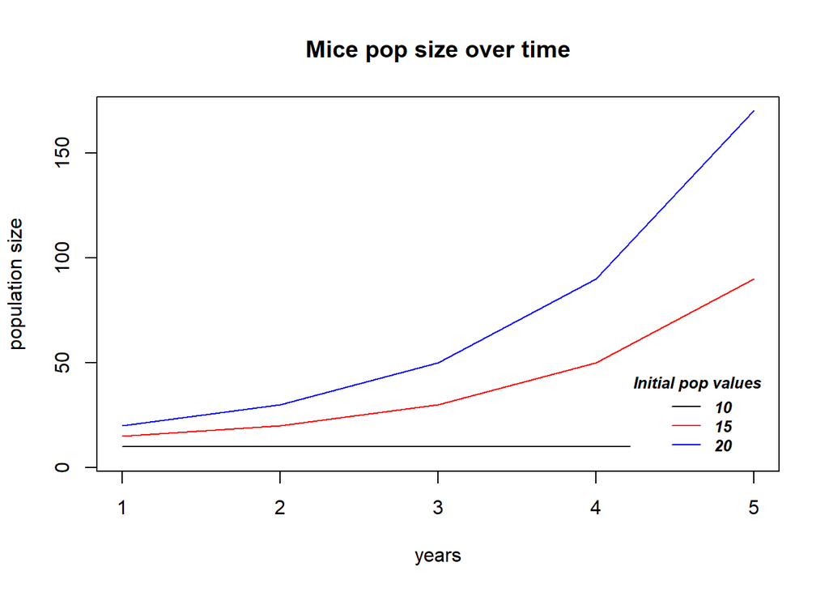

```r
##### Examples #####

init_pop <- c(10,15,20) # vector of initial pop sizes

num_timesteps <- 5 # number of time steps

popsize_mat <- matrix(0,nrow = num_timesteps,ncol = length(init_pop)) # initialize a blank matrix based on the parameters above


popsize_mat[1,] <- init_pop # set first row to be the initial pop sizes


for( j in 1:ncol(popsize_mat)){ # for every column
  for( i in 1:(nrow(popsize_mat)-1)){ # for every row (the -1 is a correction to match up the number of times iterated to account for the space taken by the preset initial value)
    popsize_mat[i+1,j] <- popsize_mat[i,j]*2 - 10 # perform the operation for the specified cell in the matrix and output the result to the next row in the same column
  }
}

### Plotting Results ###

plot(popsize_mat[,1],type='l',col='black',ylim = c(0.5*min(popsize_mat),max(popsize_mat)), main = "Mice pop size over time", xlab= "years", ylab="population size") # make plot
lines(popsize_mat[,2],type = "l", col = 'red')# overlay second line
lines(popsize_mat[,3],type = "l", col = 'blue') # overlay 3rd line
  legend("bottomright",legend = popsize_mat[1,], col = c('black','red','blue'),lty = 1,cex = 0.8, title = "Initial pop values", text.font = 4, box.lty = 0, inset = 0.02) # make legend
```

```r
print(popsize_mat)
```

```
##      [,1] [,2] [,3]
## [1,]   10   15   20
## [2,]   10   20   30
## [3,]   10   30   50
## [4,]   10   50   90
## [5,]   10   90  170
```

Create the following model:

Every day, the population of bacteria in a culture doubles. Before the cells divide, 100 bacteria will be killed by penicillin. Another 100 bacteria are killed at the end of each day after division. There are 5 bacteria cultures with population sizes of 100, 200,300,400 and 500, respectively. What will happen to these populations after 5 days?

```r
###### YOUR CODE HERE ######
```

Answer: pop sizes after 5 days for each initial pop: -2900 -1300 300 1900 3500 (negative pop size is basically 0)

6. Using rbinom() as a random sample generator

For our lab, we’ll want to simulate genetic drift through binomial random sampling. The binomial distribution B(n,p) takes two parameters: n = the size of the pool to sample from, and p = the probability of sampling a desired object. Let’s think of this as a bag of red and blue marbles. If we know that the bag can hold 10 marbles, and that 6 of the marbles are red, then we can create a random sampling distribution for red marbles with B(10,0.6).

In R, the rbinom() function lets us randomly generate a binomial sample by specifying n and p for B(n,p). We can also provide rbinom() the number of samples that we want to take from the distribution.

For example: if there is a bag of 4 red marbles and 6 blue, then we run rbinom(1,10,0.4) we will get random numbers between 1 and 10 that should average to be around 4.

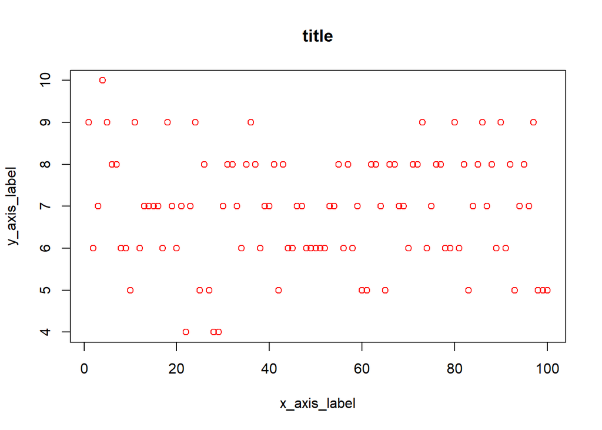

```r
##### Examples #####
number_samples <- 100 # number of samples to draw from bag with replacement

num_redmarbles_drawn = rep(0,number_samples) # initialize vector

size_samplingpool <- 10 # a pool of 10 marbles

prob_reds <- 0.7 # probability of getting a red marble


for(i in 1:length(num_redmarbles_drawn)){
 num_redmarbles_drawn[i] <- rbinom(1,size_samplingpool,prob_reds) # for every index in vector, draw 1 sample from the distribution of red marbles in the bag (a number between 1 and 10 that averages 7)
}

plot(num_redmarbles_drawn, main = "title", xlab ="x_axis_label", ylab= "y_axis_label", col = "red")
```

```r
print(mean(num_redmarbles_drawn))
```

```
## [1] 6.92
```

Let’s say there are 100 people in a population and we want to draw samples from a single locus with only 2 possible alleles, A and B.

If the allele frequency of A is 0.79, create a vector of 10 random samples of B.

```r
###### YOUR CODE HERE ######
```

Answer: 10 random numbers between 1 and 100 with an average around the allele frequency of B.

## Revisiting linear regression

Now we will be reviewing the R code used in last week’s linear regression module. We will be using `ggplot2` for prettier plots and reading two data files provided alongside this code. Make sure to install the appropriate packages and modify the file paths before running the following code!

### Infant Height and Age

```r
# Check if ggplot2 is already installed
if (!require(ggplot2, quietly = TRUE)) {
  # If it's not installed, install it
  install.packages("ggplot2")

  # Load the package after installation
  library(ggplot2)
} else {
  # If it's already installed, simply load the library
  library(ggplot2)
}
```

#### Simple linear regression

```r
ageandheight <- read.csv("ageandheight.csv") #Read the data
lmHeight = lm(height~age, data = ageandheight) #Create the linear regression
summary(lmHeight) #Review the results
```

```
##
## Call:
## lm(formula = height ~ age, data = ageandheight)
##
## Residuals:
##      Min       1Q   Median       3Q      Max
## -0.27238 -0.24248 -0.02762  0.16014  0.47238
##
## Coefficients:
##             Estimate Std. Error t value Pr(>|t|)
## (Intercept)  64.9283     0.5084  127.71  < 2e-16 ***
## age           0.6350     0.0214   29.66 4.43e-11 ***
## ---
## Signif. codes:  0 '***' 0.001 '**' 0.01 '*' 0.05 '.' 0.1 ' ' 1
##
## Residual standard error: 0.256 on 10 degrees of freedom
## Multiple R-squared:  0.9888, Adjusted R-squared:  0.9876
## F-statistic:   880 on 1 and 10 DF,  p-value: 4.428e-11
```

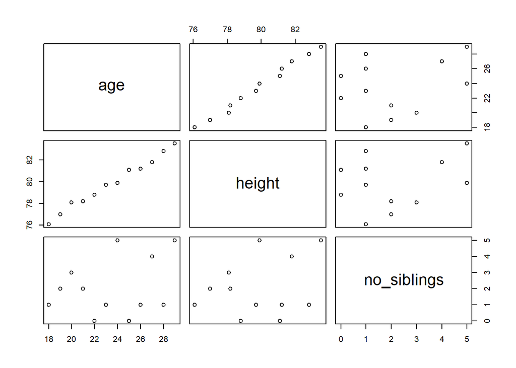

```r
plot(ageandheight)
```

Interpret the regression results.

1. What does the estimate mean?
2. What us the p-value of the estimate? What does that represent?
3. What is the R-squared? What does that represent?
4. Is the regression line a good fit for this data?

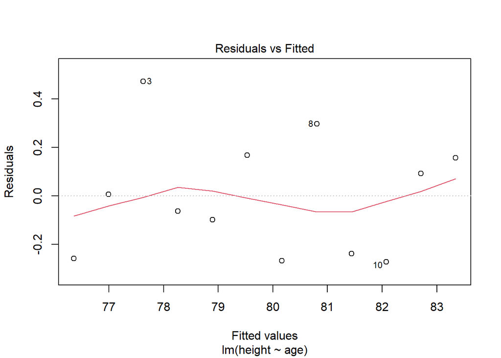

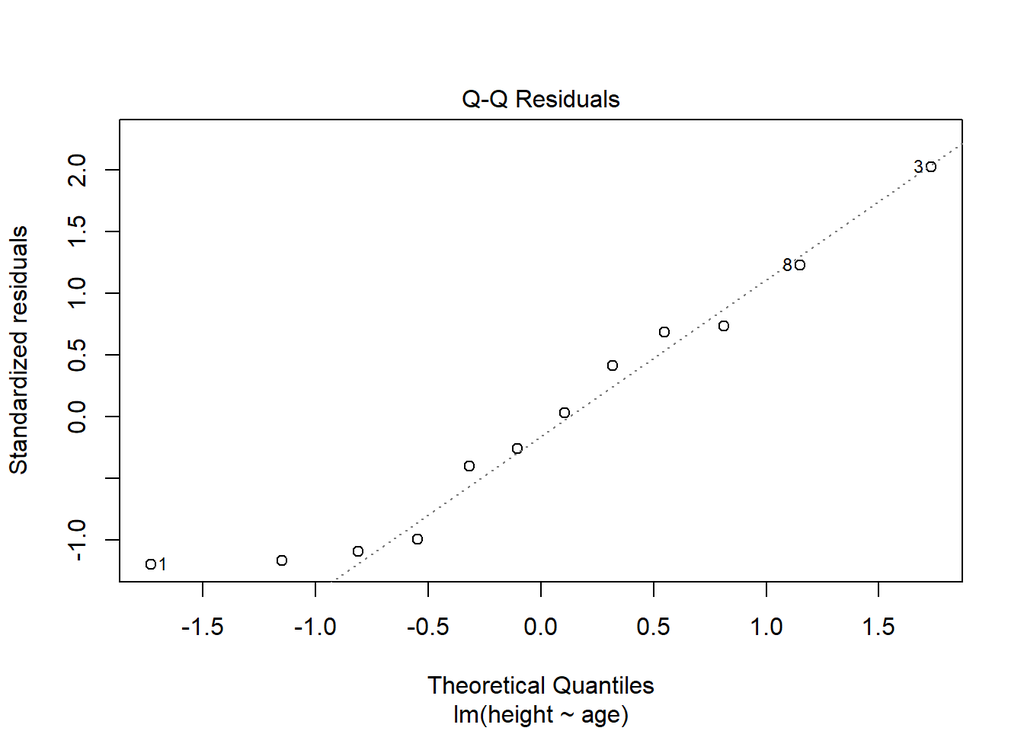

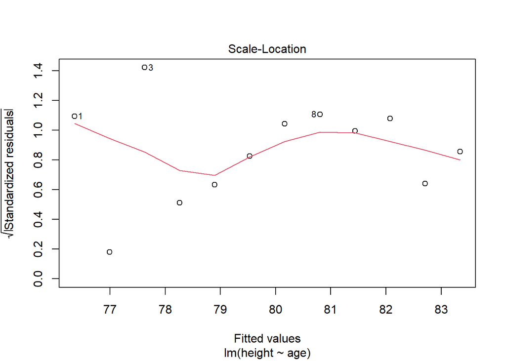

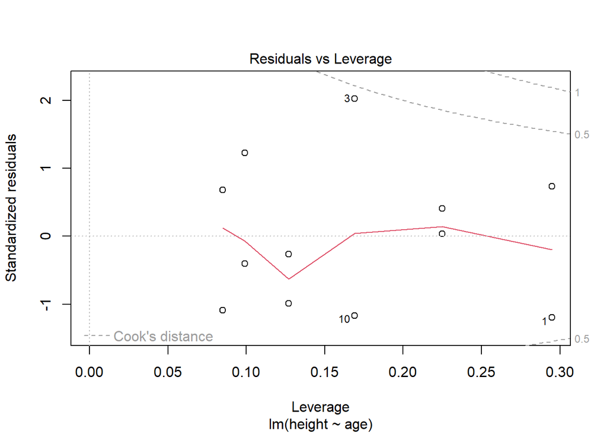

```r
plot(lmHeight)
```

Review these additional regression summary figures. What does each tell us about the quality of our fit?

#### Visualize with `ggplot2`

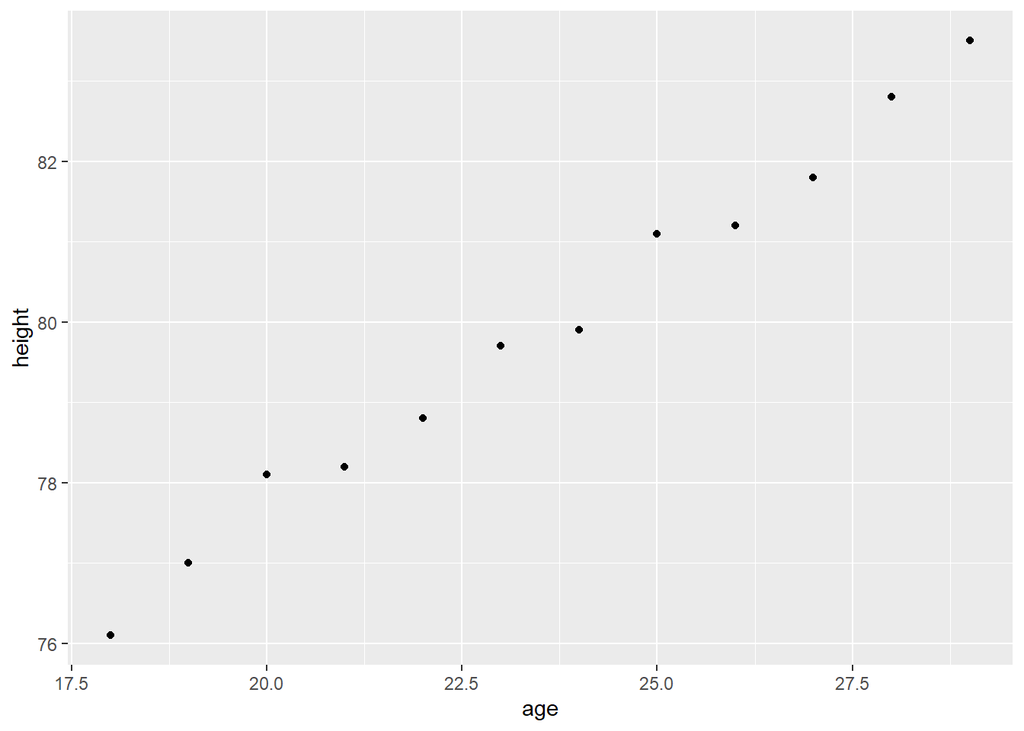

```r
# Create a scatterplot of the data
ggplot(ageandheight, aes(x = age, y = height)) +
  geom_point()
```

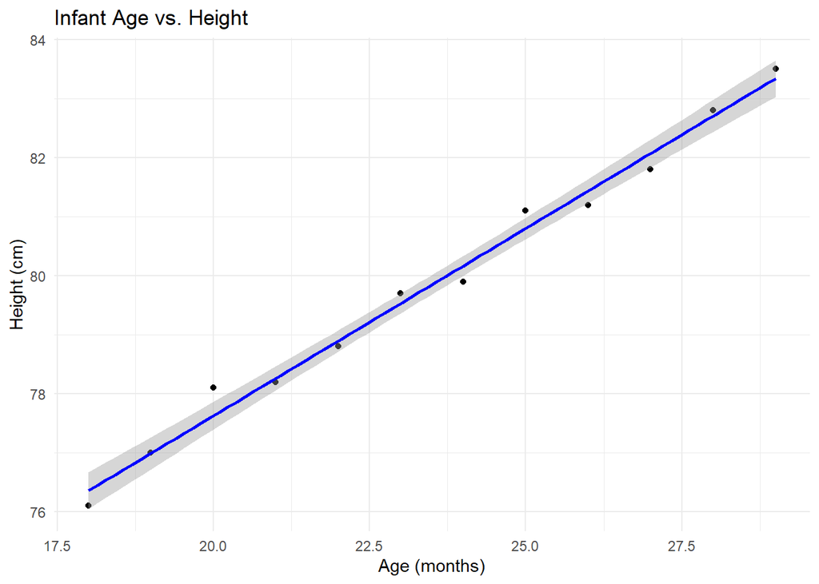

```r
# Create a scatterplot of the data
scatter_plot <- ggplot(ageandheight, aes(x = age, y = height)) +
  geom_point() +
  geom_smooth(method = "lm",
              color = "blue",
              se = TRUE,
              level = 0.95,
              formula = y ~ x) # Add linear regression line with CI

# Customize the plot appearance and add regression info
scatter_plot +
  labs(title = "Infant Age vs. Height",
                    x = "Age (months)",
                    y = "Height (cm)") +
  theme_minimal()
```

What are the (aesthetic) differences between each produced plot?

#### Multivariable linear regression

```r
lmHeight2 = lm(height~age + no_siblings, data = ageandheight) #Create a linear regression with two variables
summary(lmHeight2) #Review the results
```

```
##
## Call:
## lm(formula = height ~ age + no_siblings, data = ageandheight)
##
## Residuals:
##      Min       1Q   Median       3Q      Max
## -0.26297 -0.22462 -0.02021  0.16102  0.49752
##
## Coefficients:
##             Estimate Std. Error t value Pr(>|t|)
## (Intercept) 64.90554    0.53526 121.260 8.96e-16 ***
## age          0.63751    0.02340  27.249 5.85e-10 ***
## no_siblings -0.01772    0.04735  -0.374    0.717
## ---
## Signif. codes:  0 '***' 0.001 '**' 0.01 '*' 0.05 '.' 0.1 ' ' 1
##
## Residual standard error: 0.2677 on 9 degrees of freedom
## Multiple R-squared:  0.9889, Adjusted R-squared:  0.9865
## F-statistic: 402.2 on 2 and 9 DF,  p-value: 1.576e-09
```

What does the regression summary tell us? 1. What does the estimate mean? 2. What us the p-value of the estimate? What does that represent? 3. What is the R-squared? What does that represent? 4. Is the regression line a good fit for this data?

Is one variable more predictive of height than the other? Which one? How do you know?

## Revisiting linear regression

Now we will perform a similar linear regression analysis using a more complex data set. The data is provided alongside this code. The following blank sections are included to help organize your analysis, but feel free to try out several combinations of variable predictors and add code blocks for each. This is meant to be a sandbox analysis. Proceed in any way you see fit.

**STUDY DESIGN:**

We collect various measurements and predictors of cardiovascular disease risk from a cohort of *N=100* patients, including patients with and without Coronary Artery Disease (CAD). CAD is the most common type of heart disease in the United States and a leading cause of heart attack. Individuals with CAD have abnormal plaque buildup in the walls of the coronary arteries, which supply blood to the muscles of the heart. We are interested in identifying important predictors of CAD by assessing demographic, physiologic and genetic risk factors. For the latter, we determined the total number of CAD genetic risk variants for each patient by performing whole genome sequencing on blood samples obtained during the study visit and comparing with published genome wide association studies for CAD.

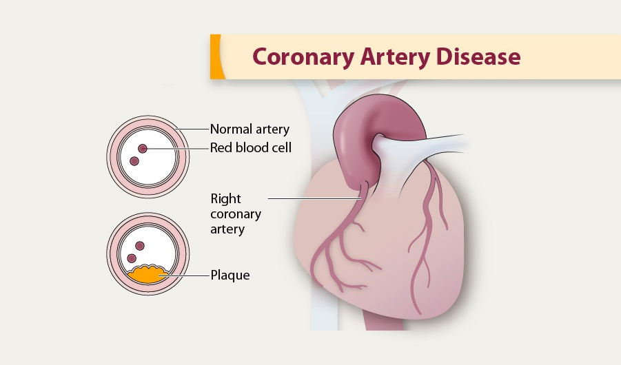

CDC: Coronary Artery Disease

Our CAD data contains the following variables: * Age: patient age

- Systolic_BP: systolic blood pressure at study visit
- Diastolic_BP: diastolic blood pressure at study visit
- Total_Cholesterol: total cholesterol at study visit
- HDL_Cholesterol: HDL cholesterol at study visit
- LDL_Cholesterol: LDL cholesterol at study visit
- Diabetes: diabetes history (0 = not diabetic, 1 = diabetic)
- Smoking: smoking history (0 = never smoker, 1 = former smoker, 2 = current smoker)
- SumRiskVariants: total number of CAD genetic risk variants as determined by comparison with GWAS
- CAD: coronary artery disease diagnosis (0 = healthy, 1 = CAD)

**TIPS**

Reference the last section for help with performing the regressions below. For each section, interpret the model summaries and record the estimate, p-values, and R-squared for each regression.

**Logistic regression example** If you plan to use non-continous varibles in your regressions, you will need to modify the previous section’s code to perform a logistic regression. The following example shows a simple way to compute logistic regression. Feel free to modify this code for your analysis.

```r
# Generate example data
set.seed(123)
n <- 100  # Number of data points
x <- rnorm(n, mean = 0, sd = 1)  # Independent variable
y <- rbinom(n, size = 1, prob = 1 / (1 + exp(-(-1 + 2 * x))))  # Simulated binary dependent variable

# Create a data frame
data <- data.frame(x = x, y = as.factor(y))

# Fit a logistic regression model
model <- glm(y ~ x, data = data, family = binomial)

# print summary stats
summary(model)
```

```
##
## Call:
## glm(formula = y ~ x, family = binomial, data = data)
##
## Coefficients:
##             Estimate Std. Error z value Pr(>|z|)
## (Intercept)  -0.9961     0.2887  -3.451 0.000559 ***
## x             2.0262     0.4205   4.819 1.44e-06 ***
## ---
## Signif. codes:  0 '***' 0.001 '**' 0.01 '*' 0.05 '.' 0.1 ' ' 1
##
## (Dispersion parameter for binomial family taken to be 1)
##
##     Null deviance: 131.79  on 99  degrees of freedom
## Residual deviance:  90.54  on 98  degrees of freedom
## AIC: 94.54
##
## Number of Fisher Scoring iterations: 5
```

#### Simple linear regression

```r
cardio_data <- read.csv("CAD.csv") #Read the data
head(cardio_data)
```

```
##        Age Systolic_BP Diastolic_BP Total_Cholesterol HDL_Cholesterol
## 1 61.36698    140.7343     80.02255          198.8281        49.95724
## 2 60.71314    139.5808     79.09630          198.9795        49.05168
## 3 60.05750    141.0263     79.38657          200.3276        49.56014
## 4 60.99825    140.3776     79.72129          201.3725        50.55517
## 5 59.84627    140.2601     80.30753          198.9939        49.02473
## 6 58.59579    139.3366     78.18687          199.1532        48.49979
##   LDL_Cholesterol Diabetes Smoking SumRiskVariants CAD
## 1       100.86742        1       2              31   1
## 2        99.37565        0       1              25   0
## 3        99.04382        1       1              25   0
## 4       100.29880        1       1              25   0
## 5        99.97659        0       2              29   0
## 6        97.96512        0       1              23   0
```

```r
###### YOUR CODE HERE ######
```

#### Visualize with `ggplot2`

```r
###### YOUR CODE HERE ######
```

#### Multivariable linear regression

**Main Question:** Which factors are most important for predicting CAD risk? What are their effect sizes (i.e. estimates)?

```r
###### YOUR CODE HERE ######
```